# Distributions in R

# 1 Introduction

We will create Distributions for data in R. As always, we will consistently use the [**Project Mosaic**](https://mosaic-web.org) ecosystem of packages in R (`mosaic`, `mosaicData` and `ggformula`).

Note the standard method for all commands from the `mosaic` package:

goal( y ~ x | z, data = mydata, …)

## 1.1 Case Study -1: Dataset from `mosaicData`

Let us inspect what datasets are available in the package `mosaicData`. Type `data(package = "mosaicData")` in your Console to see what datasets are available.

Let us choose the famous `Galton` dataset:

```r
data("Galton")
inspect(Galton)
```

```
#>
#> categorical variables:
#>     name  class levels   n missing
#> 1 family factor    197 898       0
#> 2    sex factor      2 898       0
#>                                    distribution
#> 1 185 (1.7%), 166 (1.2%), 66 (1.2%) ...
#> 2 M (51.8%), F (48.2%)
#>
#> quantitative variables:
#>     name   class min Q1 median   Q3  max      mean       sd   n missing
#> 1 father numeric  62 68   69.0 71.0 78.5 69.232851 2.470256 898       0
#> 2 mother numeric  58 63   64.0 65.5 70.5 64.084410 2.307025 898       0
#> 3 height numeric  56 64   66.5 69.7 79.0 66.760690 3.582918 898       0
#> 4  nkids integer   1  4    6.0  8.0 15.0  6.135857 2.685156 898       0
```

The data is described as a data frame with 898 observations on the following variables.

> - `family` a factor with levels for each family
> - `father` the father’s height (in inches)
> - `mother` the mother’s height (in inches)
> - `sex` the child’s sex: F or M
> - `height` the child’s height as an adult (in inches)
> - `nkids` the number of adult children in the family, or, at least, the number whose heights Galton recorded.

There is a lot of Description generated by the `mosaic::inspect()` command ! What can we say about the dataset and its variables? How big is the dataset? How many variables? What types are they, Quant or Qual? If they are Qual, what are the *levels*? Are they *ordered* levels? Discuss!

### 1.1.1 Stat Summaries

As Stigler said, **summaries** are the first thing to look at in data. Let us tabulate some quick stat summaries of the important variables in `Galton`:

```r
favstats(~ father, data = Galton)
```

|  | min | Q1 | median | Q3 | max | mean | sd | n | missing |
| --- | --- | --- | --- | --- | --- | --- | --- | --- | --- |
|  | 62 | 68 | 69 | 71 | 78.5 | 69.23285 | 2.470256 | 898 | 0 |

```r
favstats(~ height | sex, data = Galton)
```

| sex | min | Q1 | median | Q3 | max | mean | sd | n | missing |
| --- | --- | --- | --- | --- | --- | --- | --- | --- | --- |
| F | 56 | 62.5 | 64.0 | 65.5 | 70.5 | 64.11016 | 2.370320 | 433 | 0 |
| M | 60 | 67.5 | 69.2 | 71.0 | 79.0 | 69.22882 | 2.631594 | 465 | 0 |

Q.1 How many families in the data for each value of `nkids`?

```r
tally(~ nkids, data = Galton)
```

```
#> nkids
#>   1   2   3   4   5   6   7   8   9  10  11  15
#>  32  40  66 116 140 114 112 128  63  40  32  15
```

Q.2. What is the break-up by `sex` of the child?

```r
tally(~ nkids | sex, data = Galton)
```

```
#>      sex
#> nkids  F  M
#>    1  15 17
#>    2  18 22
#>    3  31 35
#>    4  48 68
#>    5  61 79
#>    6  57 57
#>    7  61 51
#>    8  61 67
#>    9  32 31
#>    10 24 16
#>    11 17 15
#>    15  8  7
```

### 1.1.2 Distribution Plots

What Questions might we have, that we could answer with a Distribution?

Q.1 How many families based on the number of children?

```r
# Convert the tally into a dataframe. See the difference!
family_count <- tally( ~ nkids | sex, data = Galton) %>%
  as_tibble() %>%

  # Convert nkids from char to int
  mutate( nkids = as.integer(nkids))
family_count
```

| nkids | sex | n |
| --- | --- | --- |
| 1 | F | 15 |
| 2 | F | 18 |
| 3 | F | 31 |
| 4 | F | 48 |
| 5 | F | 61 |
| 6 | F | 57 |
| 7 | F | 61 |
| 8 | F | 61 |
| 9 | F | 32 |
| 10 | F | 24 |

[output cut: 14 more lines]

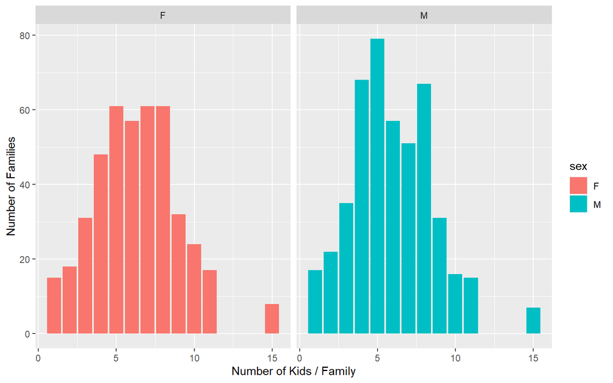

```r
gf_col(n ~ nkids | sex, data = family_count, fill = ~ sex, ylab = "Number of Families", xlab = "Number of Kids / Family")
```

Q.2: How are the children’s heights distributed?

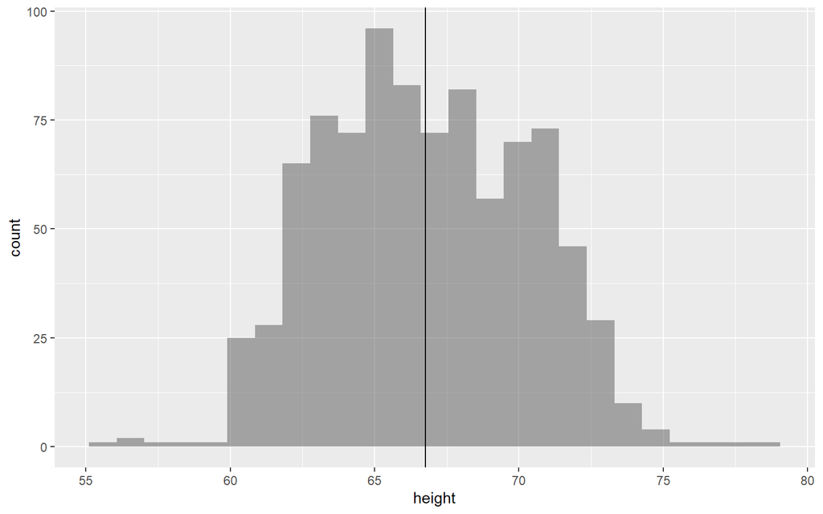

```r
gf_histogram(~ height, data = Galton) %>%
  gf_vline(xintercept = mean(Galton$height))
```

Q.3: Is there a difference in height distributions between Male and Female children?

```r
measures <- favstats(~ height | sex, data = Galton)
measures
```

| sex | min | Q1 | median | Q3 | max | mean | sd | n | missing |
| --- | --- | --- | --- | --- | --- | --- | --- | --- | --- |
| F | 56 | 62.5 | 64.0 | 65.5 | 70.5 | 64.11016 | 2.370320 | 433 | 0 |
| M | 60 | 67.5 | 69.2 | 71.0 | 79.0 | 69.22882 | 2.631594 | 465 | 0 |

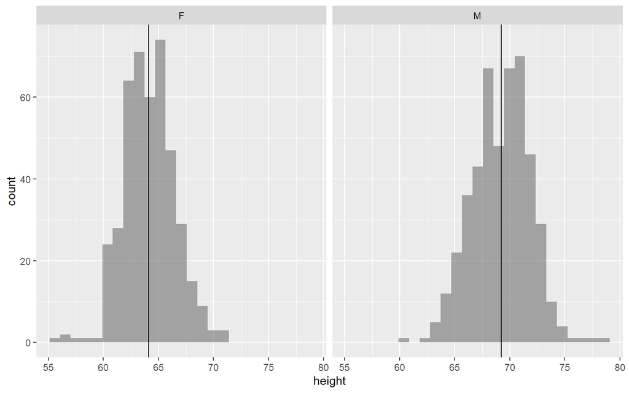

```r
gf_histogram(~ height | sex, data = Galton) %>%
  gf_vline(xintercept = ~ mean, data = measures)
```

Q.4: Are Mothers generally shorter than fathers?

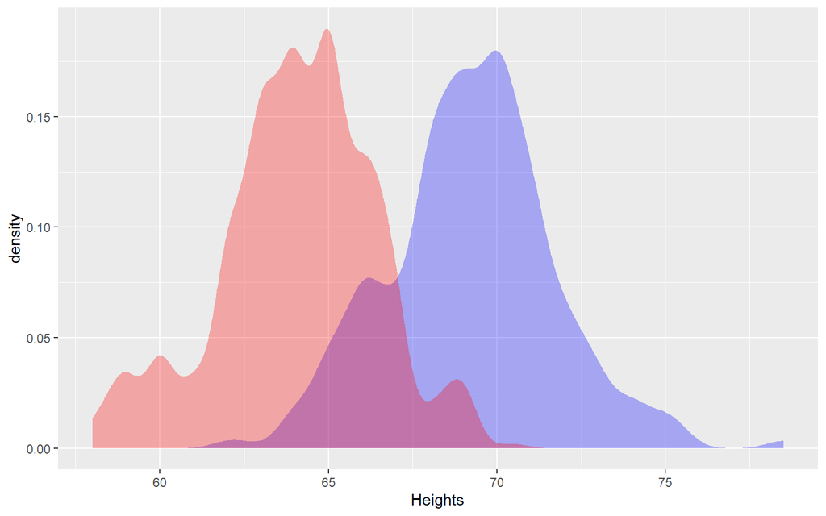

```r
gf_density(~ father, data = Galton, fill = "blue", alpha = 0.3) %>%
  gf_density( ~ mother, data = Galton, fill = "red", alpha = 0.3, xlab = "Heights")
```

Q.5: Are heights of children different based on the number of kids in the family? For Male and Female children?

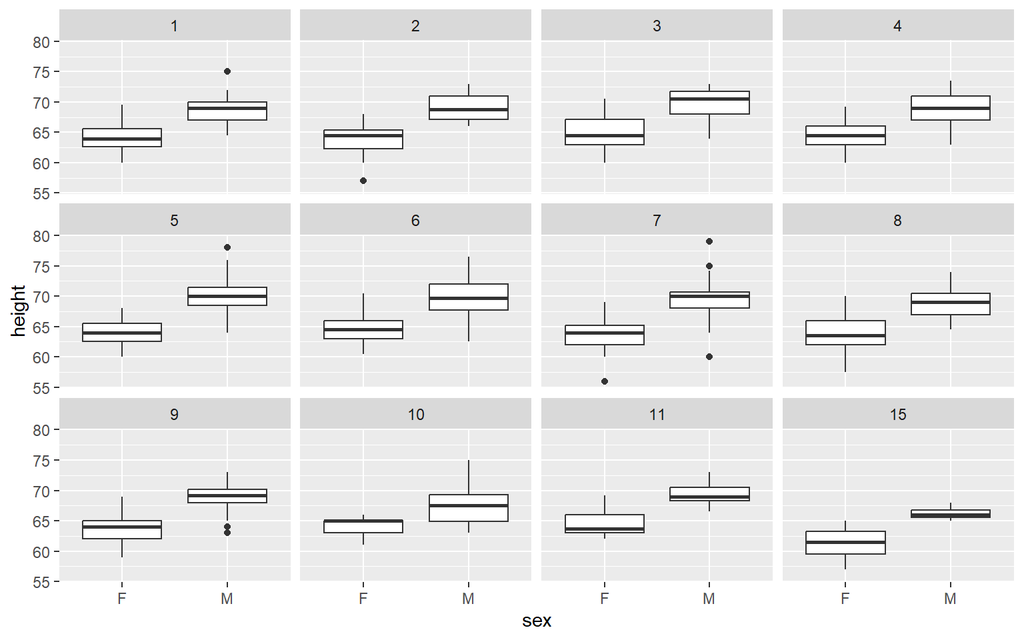

```r
gf_boxplot(height ~ sex | nkids, data = Galton)
```

Q.6: Does the **mean** height of children in a family vary with the number of children in the family? ( family size)

```r
mean( height ~ sex | nkids, data = Galton) %>% as_tibble() # not very inspiring!
```

| value |
| --- |
| 64.32667 |
| 68.84706 |
| 63.92222 |
| 68.83182 |
| 64.89677 |
| 69.66286 |
| 64.45000 |
| 69.05441 |
| 63.97213 |
| 69.94684 |

[output cut: 26 more lines]

```r
by_sex_nkids <- favstats( height ~ sex + nkids, data = Galton)
by_sex_nkids # much better!
```

| sex.nkids | min | Q1 | median | Q3 | max | mean | sd | n | missing |
| --- | --- | --- | --- | --- | --- | --- | --- | --- | --- |
| F.1 | 60.0 | 62.600 | 64.00 | 65.600 | 69.5 | 64.32667 | 2.423535 | 15 | 0 |
| M.1 | 64.5 | 67.000 | 69.00 | 70.000 | 75.0 | 68.84706 | 2.631330 | 17 | 0 |
| F.2 | 57.0 | 62.250 | 64.50 | 65.425 | 68.0 | 63.92222 | 2.753726 | 18 | 0 |
| M.2 | 66.0 | 67.125 | 68.75 | 70.925 | 73.0 | 68.83182 | 2.075798 | 22 | 0 |
| F.3 | 60.0 | 63.000 | 64.50 | 67.100 | 70.5 | 64.89677 | 2.650344 | 31 | 0 |
| M.3 | 64.0 | 68.000 | 70.50 | 71.750 | 73.0 | 69.66286 | 2.589354 | 35 | 0 |
| F.4 | 60.0 | 63.000 | 64.50 | 66.000 | 69.2 | 64.45000 | 2.535703 | 48 | 0 |
| M.4 | 63.0 | 67.000 | 69.00 | 71.000 | 73.5 | 69.05441 | 2.500115 | 68 | 0 |
| F.5 | 60.0 | 62.500 | 64.00 | 65.500 | 68.0 | 63.97213 | 2.004173 | 61 | 0 |
| M.5 | 64.0 | 68.500 | 70.00 | 71.500 | 78.0 | 69.94684 | 2.477428 | 79 | 0 |

[output cut: 14 more lines]

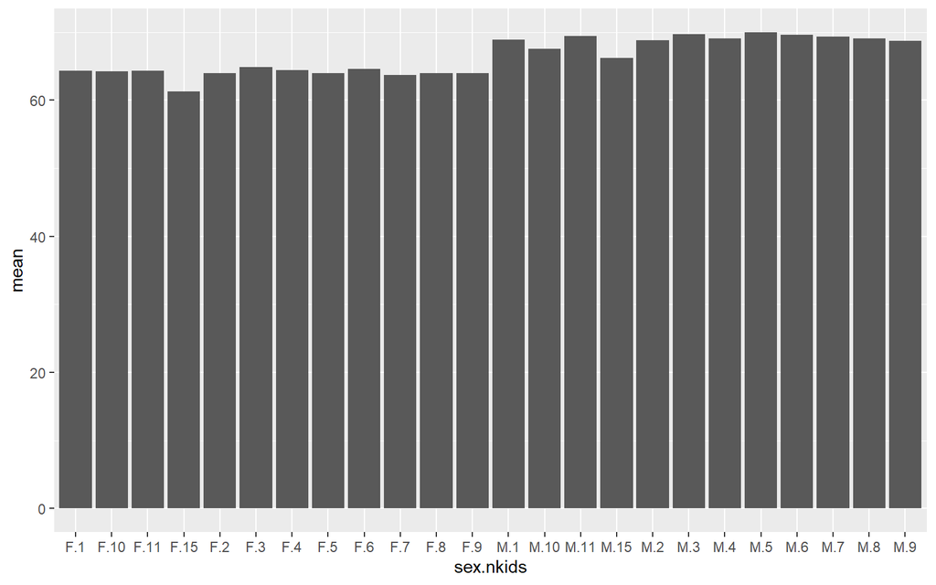

```r
gf_col(mean ~ sex.nkids, data = by_sex_nkids)
```

Hmm…not a *very* informative plot…

## 1.2 Case Study-2: Dataset from `NHANES`

Let us try the `NHANES` dataset. Try `help(NHANES)` in your Console.

```r
data("NHANES")
names(NHANES)
```

```
#>  [1] "ID"               "SurveyYr"         "Gender"           "Age"
#>  [5] "AgeDecade"        "AgeMonths"        "Race1"            "Race3"
#>  [9] "Education"        "MaritalStatus"    "HHIncome"         "HHIncomeMid"
#> [13] "Poverty"          "HomeRooms"        "HomeOwn"          "Work"
#> [17] "Weight"           "Length"           "HeadCirc"         "Height"
#> [21] "BMI"              "BMICatUnder20yrs" "BMI_WHO"          "Pulse"
#> [25] "BPSysAve"         "BPDiaAve"         "BPSys1"           "BPDia1"
#> [29] "BPSys2"           "BPDia2"           "BPSys3"           "BPDia3"
#> [33] "Testosterone"     "DirectChol"       "TotChol"          "UrineVol1"
#> [37] "UrineFlow1"       "UrineVol2"        "UrineFlow2"       "Diabetes"
#> [41] "DiabetesAge"      "HealthGen"        "DaysPhysHlthBad"  "DaysMentHlthBad"
#> [45] "LittleInterest"   "Depressed"        "nPregnancies"     "nBabies"
#> [49] "Age1stBaby"       "SleepHrsNight"    "SleepTrouble"     "PhysActive"
#> [53] "PhysActiveDays"   "TVHrsDay"         "CompHrsDay"       "TVHrsDayChild"
#> [57] "CompHrsDayChild"  "Alcohol12PlusYr"  "AlcoholDay"       "AlcoholYear"
#> [61] "SmokeNow"         "Smoke100"         "Smoke100n"        "SmokeAge"
#> [65] "Marijuana"        "AgeFirstMarij"    "RegularMarij"     "AgeRegMarij"
#> [69] "HardDrugs"        "SexEver"          "SexAge"           "SexNumPartnLife"
#> [73] "SexNumPartYear"   "SameSex"          "SexOrientation"   "PregnantNow"
```

### 1.2.1 Stat Summaries

```r
mosaic::inspect(NHANES)
```

```
#>
#> categorical variables:
#>                name  class levels     n missing
#> 1          SurveyYr factor      2 10000       0
#> 2            Gender factor      2 10000       0
#> 3         AgeDecade factor      8  9667     333
#> 4             Race1 factor      5 10000       0
#> 5             Race3 factor      6  5000    5000
#> 6         Education factor      5  7221    2779
#> 7     MaritalStatus factor      6  7231    2769
#> 8          HHIncome factor     12  9189     811
#> 9           HomeOwn factor      3  9937      63
#> 10             Work factor      3  7771    2229
#> 11 BMICatUnder20yrs factor      4  1274    8726
#> 12          BMI_WHO factor      4  9603     397
```

[output cut: 145 more lines]

Again, lots of data from `inspect`, about the Quant and Qual variables. Spend a little time looking through the output of `inspect`. Which variables could have been data *given* by each respondent, and which ones could have been *measured* data variables? Why do you think so?  
Why is there so much *missing* data? Which variable are the most affected by this?

```r
tally(Education ~ Work, data = NHANES)
```

```
#>                 Work
#> Education        Looking NotWorking Working <NA>
#>   8th Grade           13        249     188    1
#>   9 - 11th Grade      39        438     411    0
#>   High School         52        579     886    0
#>   Some College        88        792    1387    0
#>   College Grad        72        474    1552    0
#>   <NA>                47        315     189 2228
```

### 1.2.2 Distribution Plots

Q.1. What is the distribution of Physical Activity Days, across Gender? Across Education?

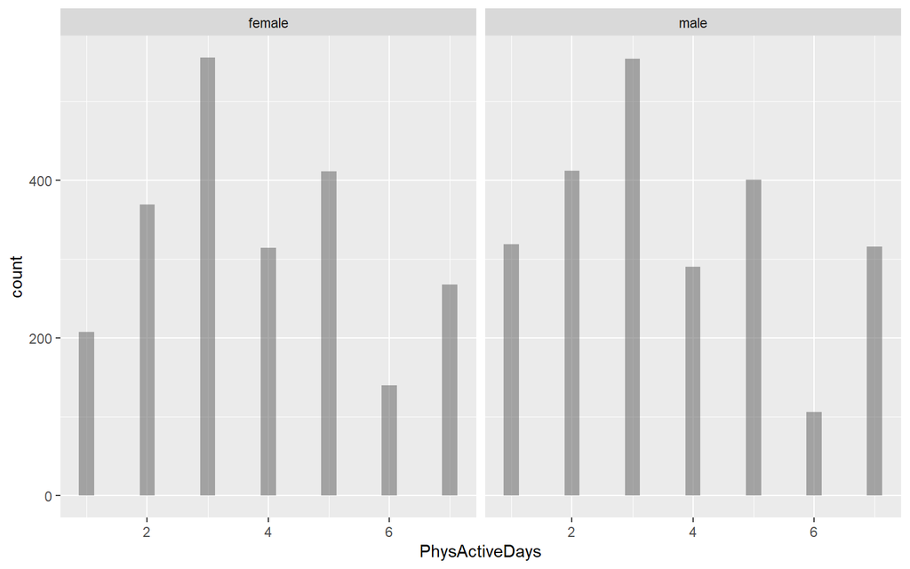

```r
gf_histogram(data = NHANES, ~ PhysActiveDays | Gender)
```

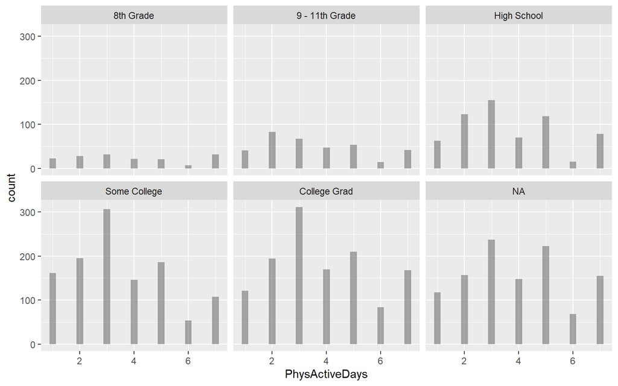

```r
gf_histogram(data = NHANES, ~ PhysActiveDays | Education)
```

Q.1. How are people Ages distributed across levels of Education?

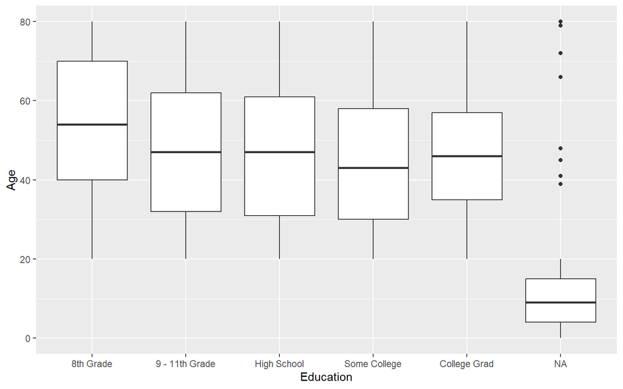

```r
gf_boxplot(Age ~ Education, data = NHANES)
```

```r
gf_histogram()
```

[output not shown]

Q.3 What is the distribution of people’s BMI, split by Gender? By Race1?

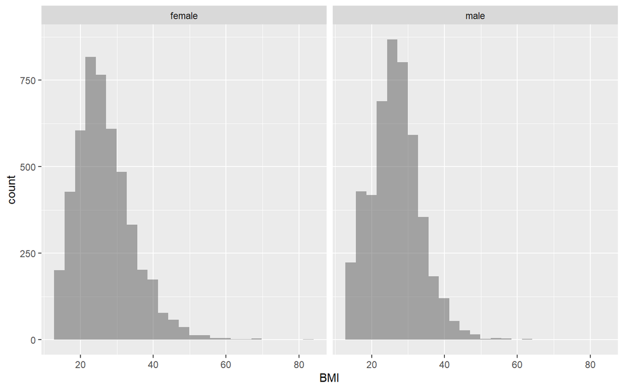

```r
gf_histogram(~ BMI | Gender, data = NHANES)
```

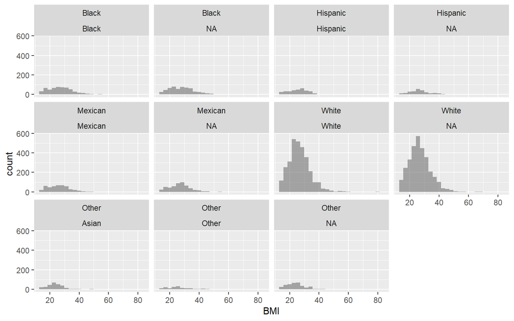

```r
gf_histogram(~ BMI | Race1 + Race3, data = NHANES)
```

## 1.3 Case Study-3: A complete example

Here is a dataset from Jeremy Singer-Vine’s blog, [Data Is Plural](https://www.data-is-plural.com/). This is a list of all books banned in schools across the US.

```r
banned <- readxl::read_xlsx(path = "data/banned.xlsx",
                            sheet = "Sorted by Author & Title")
banned
```

| Author | Title | Type of Ban | Secondary Author(s) | Illustrator(s) | Translator(s) | State | District | Date of Challenge/Removal | Origin of Challenge |
| --- | --- | --- | --- | --- | --- | --- | --- | --- | --- |
| Àbíké-Íyímídé, Faridah | Ace of Spades | Banned from Libraries and Classrooms | NA | NA | NA | Florida | Indian River County School | 44501 | Administrator |
| Acevedo, Elizabeth | Clap When You Land | Banned from Classrooms | NA | NA | NA | Pennsylvania | Central York | 44440 | Administrator |
| Acevedo, Elizabeth | The Poet X | Banned from Libraries | NA | NA | NA | Florida | Indian River County School | 44501 | Administrator |
| Acevedo, Elizabeth | The Poet X | Banned from Libraries and Classrooms | NA | NA | NA | New York | Marlboro Central School District | 44593 | Administrator |
| Acevedo, Elizabeth | The Poet X | Banned Pending Investigation | NA | NA | NA | Texas | Fredericksburg ISD | 44621 | Administrator |
| Acevedo, Elizabeth | The Poet X | Banned Pending Investigation | NA | NA | NA | Virginia | New Kent County | 44470 | Administrator |
| Aciman, André | Call Me By Your Name (Call Me By Your Name Series) | Banned Pending Investigation | NA | NA | NA | Virginia | Spotslyvania County | 44501 | Administrator |
| Acito, Marc | How I Paid for College: A Novel of Sex, Theft, Friendship & Musical Theater (Edward Zanni Series) | Banned Pending Investigation | NA | NA | NA | Florida | Indian River County School | 44501 | Administrator |
| Adeyoha, Koja | 47,000 Beads | Banned from Classrooms | Adeyoha, Angel | McGillis, Holly | NA | Pennsylvania | Central York | 44440 | Administrator |
| Adichie, Chimamanda Ngozi | Half of a Yellow Sun | Banned from Classrooms | NA | NA | NA | Michigan | Hudsonville Public Schools | 44562 | Formal Challenge |

[output cut: 1576 more lines]

```r
names(banned)
```

```
#>  [1] "Author"                    "Title"
#>  [3] "Type of Ban"               "Secondary Author(s)"
#>  [5] "Illustrator(s)"            "Translator(s)"
#>  [7] "State"                     "District"
#>  [9] "Date of Challenge/Removal" "Origin of Challenge"
```

Clearly the variables are *all* Qualitative, except perhaps for *Date of Challenge/Removal, (which in this case has been badly mangled by Excel) So we need to make **counts** based on the* levels* of the Qual variables and plot Bar/Column charts.

Let us quickly make some Stat Summaries:

```r
mosaic::inspect(banned)
```

```
#>
#> categorical variables:
#>                         name     class levels    n missing
#> 1                     Author character    797 1586       0
#> 2                      Title character   1145 1586       0
#> 3                Type of Ban character      4 1586       0
#> 4        Secondary Author(s) character     61   98    1488
#> 5             Illustrator(s) character    192  364    1222
#> 6              Translator(s) character      9   10    1576
#> 7                      State character     26 1586       0
#> 8                   District character     86 1586       0
#> 9  Date of Challenge/Removal character     15 1586       0
#> 10       Origin of Challenge character      2 1586       0
#>                                     distribution
#> 1  Kobabe, Maia (1.9%) ...
#> 2  Gender Queer: A Memoir (1.9%) ...
#> 3  Banned Pending Investigation (46.1%) ...
#> 4  Cast, Kristin (12.2%) ...
#> 5  Aly, Hatem (4.7%) ...
#> 6  Mlawer, Teresa (20%) ...
#> 7  Texas (45%), Pennsylvania (28.8%) ...
#> 8  Central York (27.8%) ...
#> 9  44440 (28.8%), 44531 (28.3%) ...
#> 10 Administrator (95.6%) ...
```

Let us try to answer this question: *What is the count of banned books by type and by US state?*

```r
banned_by_state <- banned %>% group_by(State) %>% summarise(total = n()) %>% ungroup()
banned_by_state
```

| State | total |
| --- | --- |
| Alaska | 1 |
| Arkansas | 1 |
| Florida | 204 |
| Georgia | 13 |
| Illinois | 4 |
| Indiana | 18 |
| Iowa | 4 |
| Kansas | 30 |
| Maryland | 1 |
| Michigan | 2 |

[output cut: 16 more lines]

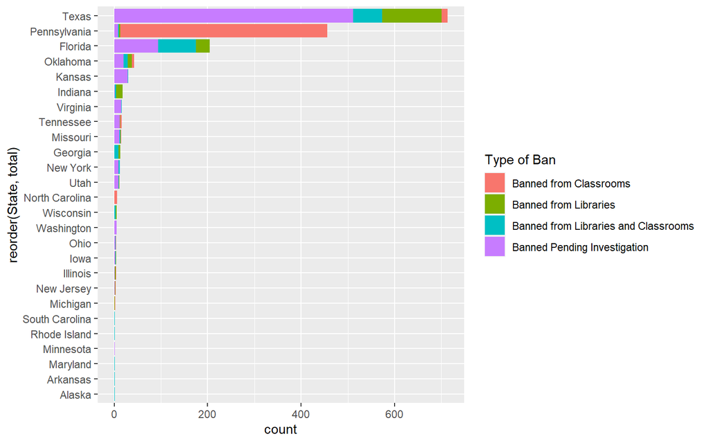

```r
banned %>% group_by(State, `Type of Ban`) %>% summarise(count = n()) %>% ungroup() %>% left_join(., banned_by_state, by = c("State" = "State")) %>%
 #  pivot_wider(.,id_cols = State,
 #              names_from = `Type of Ban`,
 #              values_from = count) %>% janitor::clean_names() %>%
 #  replace_na(list(banned_from_libraries_and_classrooms = 0,
 #                  banned_from_libraries = 0,
 #                  banned_pending_investigation = 0,
 #                  banned_from_classrooms = 0)) %>%
 # mutate(total = sum(across(where(is.integer)))) %>%
ggplot(aes(x = reorder(State, total), y = count, fill = `Type of Ban`)) + geom_col() + coord_flip()
```

# 2 References

1. A detailed analysis of the NHANES dataset, https://awagaman.people.amherst.edu/stat230/Stat230CodeCompilationExampleCodeUsingNHANES.pdf